# chapter-11

Life-Course Perspectives of Crime

## Developmental Theories

Explanatory models that track individuals throughout their lives, focusing on how and why offending starts, persists, and eventually declines

## Developmental Theories

Trajectories - A pathway in the line of development that refer to long-term patterns of behavior and are marked by a sequence of life events and transitions

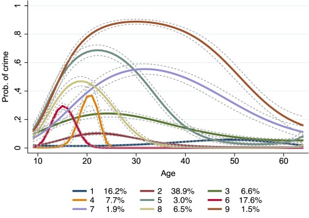

Transitions - Specific life events within trajectories (e.g., marriage, employment) that can modify the path of the trajectory

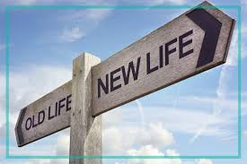

## Developmental Theories

[figure not shown]

Image: Enago

## Career Criminal Paradigm

Alfred Blumstein

Began studying the “criminal career” rather than just static snapshots of offending

Key Elements:

Onset - The age or circumstances under which offending begins

Frequency (aka Lambda) - The rate at which an individual offends

Duration - How long an individual continues to offend

Desistance - Stopping or significantly reducing criminal behavior

## Distinguishing “Criminal Career” vs. “Career Criminal”

Criminal Career

The notion that anyone’s offending can be analyzed in stages — onset, frequency, desistance - whether they offend once or a hundred times

Career Criminal

A small group of high-rate offenders who offend early, frequently, and for a long period, often with minimal desistance

## Anti-Developmental Theories

Low Self-Control Theory

Gottfredson & Hirschi (1990):

Argue that self-control is largely stable by about age 8–10 and remains relatively unchanged throughout adulthood

Low self-control manifests as impulsivity, risk-taking, and a preference for immediate gratification

According to this perspective, environmental changes (e.g., new job, marriage) do not radically shift criminal behavior

Instead individuals with low self-control will continue to engage in deviant acts under most circumstances

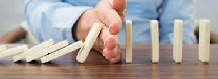

## Sampson and Laub’s Age-Graded Theory

[Sampson & Laub (1990)](https://scholar.harvard.edu/files/sampson/files/1990_asr_laub.pdf)

Model of informal social control that suggests stability and change in antisocial behavior continues throughout life

Crime is dynamic, not fixed like in low self-control theory - offending can rise and fall over time

Adult social ties matter - work, family, community bonds steer behavior, even after early risks

Two levers of change:

Turning Points – major life events (marriage, military, steady job) that can reset trajectories

Social Bonds – everyday connections to prosocial institutions

Strong bonds or positive turning points can pull individuals off a delinquent path

## Sampson and Laub’s Age-Graded Theory

| Common Turning Point | How It Re‑routes Behavior️ |
| --- | --- |
| Military service | Imposes structure, new peer group, sense of duty |
| Stable employment / career | Raises “stake in conformity,” daily routine |
| Marriage & parenthood | Increases responsibility, prosocial monitoring |
| Geographic mobility | Breaks contact with delinquent peers & settings |

# Group Discussion!!!!

## Group Discussion

`10:00`

How might evaluating one freshman cohort over 10 years (longitudinal) uncover trends in social‑media habits, mental‑health swings, student‑debt stress, and shifting friend groups - that one semester survey (cross-sectional) could never catch?

Which turning points — first serious breakup, landing (or losing) a well‑paid job, graduation into recession vs. boom — do you predict would bend those trajectories the most?

Elect one speaker to discuss

## Laub & Sampson’s “Knifing Off” Theory

Major life events can knife off past criminal routines and launch a prosocial trajectory

Mechanisms of Change

1️⃣ Structural reset – new schedules & obligations leave little time/opportunity for crime

2️⃣ Relational bonds – spouses, supervisors, or commanders apply informal social control

3️⃣ Identity shift – people adopt roles (“partner,” “parent,” “worker,” “soldier”) that clash with offending

Ex: Marriage introduces joint finances and shared responsibilities, narrowing free time and raising the social cost of arrest — reinforcing desistance.

## Local Life Circumstances Model

Horney, Osgood & Marshall 1995 – developed at UNO!!!

Offending is a dynamic response to short‑term changes in a person’s immediate social environment

Crime fluctuates with these time‑varying “local” circumstances rather than with stable traits or broad societal forces

Examples of local circumstances: shifts in relationship, employment, housing quality

Used “life-event calendar” to measure change from month to month over three years

## Thornberry’s Interactional Theory

Dynamic & Longitudinal

Delinquency is both a cause and a consequence of changing social ties across adolescence and beyond

Step 1️⃣ Weak Conventional Bonds

When attachment to family, commitment to school, and belief in mainstream values erode, a potential for delinquency emerges

Step 2️⃣ Delinquent Peers Activate Potential

Joining peer groups that model and reward deviance converts that potential into actual offending

Step 3️⃣ Self‑Reinforcing Loop

Offending further damages conventional bonds and deepens deviant peer ties, accelerating future delinquency in a feedback cycle

## Potential to Kinetic Delinquency

It may be easier to understand this with an analogy.

Step 1 (bottom of the hill), Step 2 (top of the hill), Step 3 (bottom of the hill)

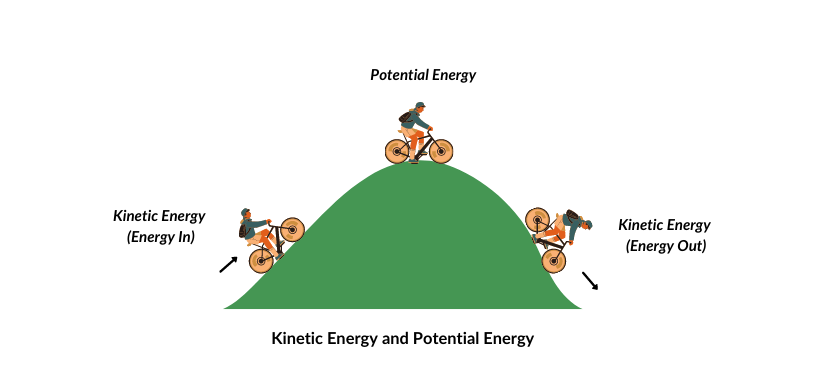

## Thornberry’s Potential

Step 1️⃣ Weak Conventional Bonds Creates Potential

[figure not shown]

## Thornberry’s Potential

Step 2️⃣ Delinquent Peers Activate Potential

[figure not shown]

## Thornberry’s Potential

Step 3️⃣ Delinquency Occurs and Loop Emerges

[figure not shown]

## Thornberry’s Interactional Theory

Summary

When social bonds weaken, they create potential for delinquency

Hanging out with delinquent peers activates that potential for delinquency

Resulting behavior that further erodes those ties, forming a self‑reinforcing loop

# Group Discussion!!!!

## Group Discussion

`10:00`

Viral TikTok stunts - like the [Kia Boyz challenges](https://en.wikipedia.org/wiki/Kia_Challenge) - draw millions of “likes” offering instant social approval.

Using Thornberry’s interactional theory, discuss how this online reinforcement can turn a teen’s weakened conventional bonds into real‑world offending and then propose one intervention (policy change, app feature, or community action) that either:

1️⃣ Strengthens conventional bonds (e.g., mentor program)

2️⃣ Disrupts the deviant peer reinforcement loop (e.g., altering the algorithm on platforms)

Elect one speaker to discuss

## Moffitt’s Developmental Taxonomy

Terrie E. Moffitt

Clinical Psychologist and Criminologist at Duke and King’s College London

One of the most [influential](https://scholar.google.com/citations?user=NR0nMHkAAAAJ&hl=en) criminologist in the field

Awarded the Stockholm Prize in Criminology

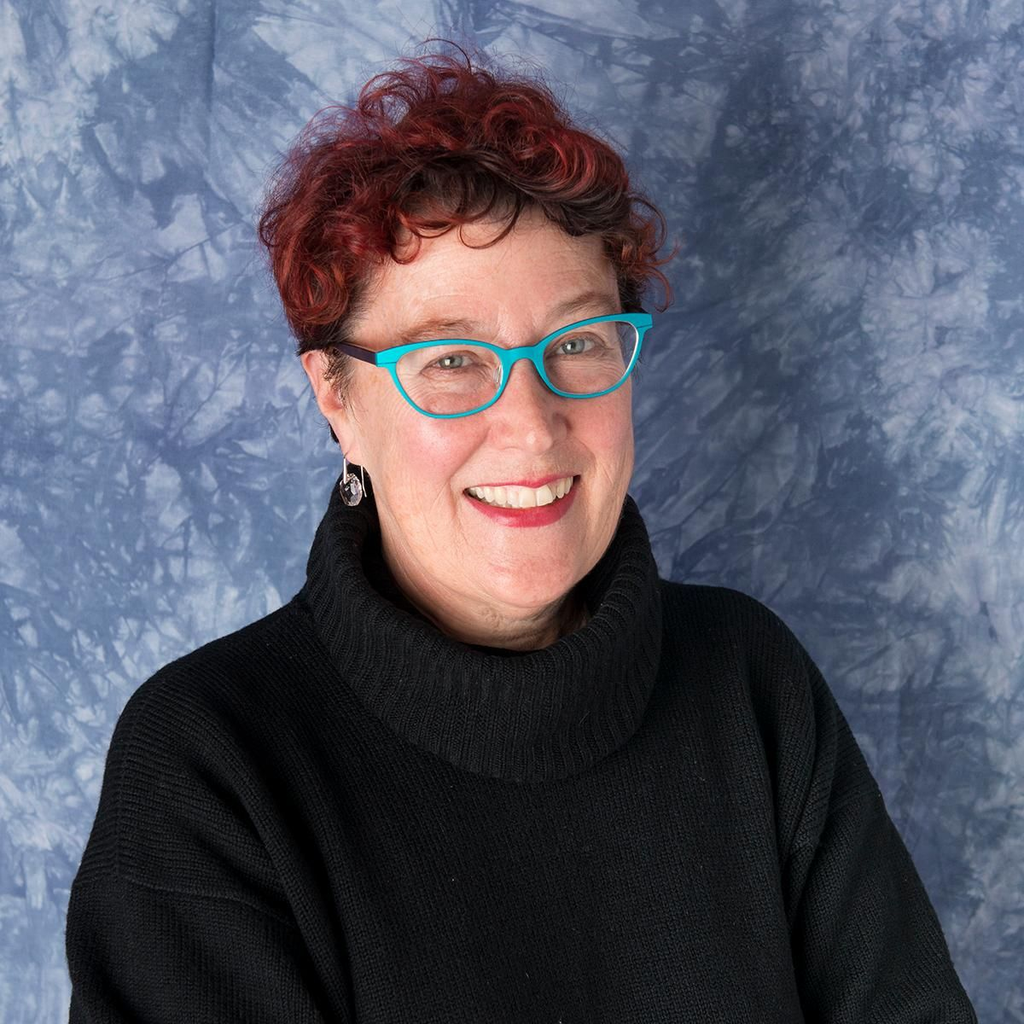

## Moffitt’s Developmental Taxonomy

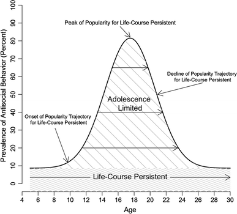

## Moffitt’s Developmental Taxonomy

Explains the age-crime curve in terms of antisocial behavior, with two types of offenders

Two Main Pathways of Offending:

Life-Course-Persistent (LCP) Offenders

Early onset of antisocial behavior (e.g., aggression, defiance in childhood)

Continue offending into adulthood

Adolescent-Limited (AL) Offenders

Begin offending during adolescence

Offending is often tied to the “maturity gap,” peer pressure, or desire for adult privileges

## The Origin of LCP Offenders

Heterotypic Continuity

A persistent underlying trait manifests in various antisocial behaviors over time

In other words, for these individuals, early behaviors (e.g., hitting, biting) will continue to evolve into more serious offenses (e.g., robbery, theft)

Causes:

Neurological risks/deficits due to prenatal and neonatal factors (e.g., maternal smoking).

Genetic heritability (e.g., ADHD).

Interaction of difficult temperament (“difficult child”) and adverse environments reinforces antisocial behavior patterns.

## Adolescent-Limited (AL) Offenders

Offending typically begins during adolescence

Driven primarily by the “maturity gap” — adolescents desire adult privileges but lack access

Influenced significantly by peer pressure and social mimicry of antisocial behaviors

They desist from crime as they enter adulthood, adopting stable social roles and responsibilities

## Biological Maturity Gap

Puberty arrives (~12-15 yrs), but full adult privileges — driving, voting, full-time work, autonomy — arrive years later

Results in a gap where adolescents feel physically mature yet are socially subordinate

This leads to social mimicry of the LCPs who have access to adult privileges (e.g., smoking, drinking, autonomy)

## Social Mimicry

Adolescents imitate antisocial behaviors to appear mature and independent

Behavior copied from peers perceived as having greater autonomy or adult-like privileges

Ex. Underage drinking and drug use to appear grown-up

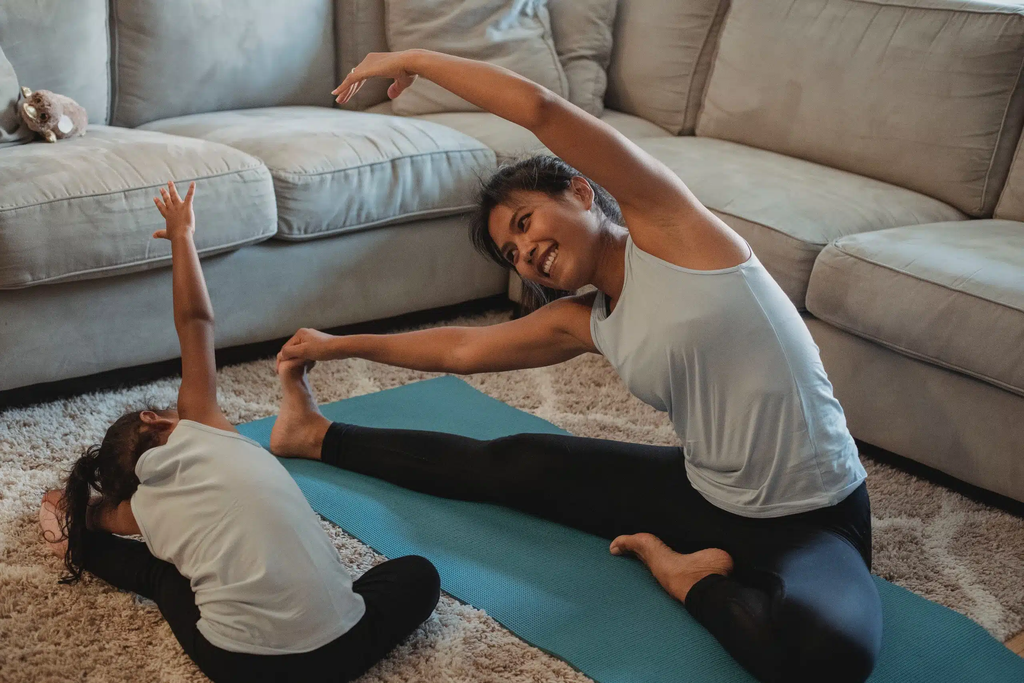

## AL and Desistance

As AL offenders age, more legitimate and tangible adult roles emerge

As a result, gradually experience a loss of motivation for delinquency and exit the maturity gap

As conventional rewards increase, motivation for crime fades and AL offending typically tapers off without formal intervention

## Abstainers

Individuals who show no recorded delinquency across adolescence

Key explanations:

Late Puberty – Less pressure to mimic older, “cool” peers

Alternative Status Sources – Respectable roles (e.g., athletics, academics, part‑time work) already confer adult‑like recognition

Protective Environments – High parental monitoring or prosocial schools limit exposure to delinquent models

Exclusion from Deviant Networks – Traits such as shyness or risk‑aversion keep them outside antisocial peer groups

## Contrast LCP and AL

| Features | LCP | AL |
| --- | --- | --- |
| Onset of Offending | Early Childhood | Adolescence |
| Duration of Offending | Persistent through adulthood | Short-term, adolescent years |
| Frequency of Offending | High and consistent | Episodic and situational |
| Causes | Neuropsychological + environment | Social mimicry, peer influence, maturity gap |

# Group Discussion!!!!

## Group Discussion

`10:00`

Considering modern issues such as social media influence, online peer pressure, and changing social dynamics, discuss how these factors might shape adolescent-limited offending today. Remember AL offending is only present in the age-crime curve spike and disappears in the early to mid twenties.

Next identify one specific intervention that would be effective for preventing a life-course-persistent offender trajectory.

Elect one speaker to discuss

## Policy Implications

LCP Offenders:

Early intervention (e.g., parenting programs, social skills training)

Specialized therapeutic and educational support for neurological and behavioral issues

AL Offenders:

Structured community programs promoting positive peer relationships

Policies targeting adolescent needs for independence and meaningful societal roles

## Have a goooooooood weekend!

[figure not shown]

Image: Giphy